# Risk Factor Analysis

## Outcome Variable

**Outcome Variable:** wast_rec90d

## Predictor Variables

**Intervention Variable:** feducyrs

**Adjustment Set:**

- arm
- W_mage
- meducyrs
- hhwealth_quart
- W_mhtcm
- W_mwtkg
- W_mbmi
- W_gagebrth
- W_birthwt
- W_birthlen
- single
- delta_W_mage
- delta_meducyrs
- delta_hhwealth_quart
- delta_W_mhtcm
- delta_W_mwtkg
- delta_W_mbmi
- delta_W_gagebrth
- delta_W_birthwt
- delta_W_birthlen
- delta_single

## Stratifying Variables

The analysis was stratified on these variable(s):

- agecat
- studyid
- country

## Data Summary

| agecat | studyid | country | feducyrs | wast_rec90d | n_cell | n |
| --- | --- | --- | --- | --- | --- | --- |
| 0-24 months | ki0047075b-MAL-ED | BANGLADESH | High | 0 | 6 | 71 |
| 0-24 months | ki0047075b-MAL-ED | BANGLADESH | High | 1 | 12 | 71 |
| 0-24 months | ki0047075b-MAL-ED | BANGLADESH | Low | 0 | 9 | 71 |
| 0-24 months | ki0047075b-MAL-ED | BANGLADESH | Low | 1 | 19 | 71 |
| 0-24 months | ki0047075b-MAL-ED | BANGLADESH | Medium | 0 | 10 | 71 |
| 0-24 months | ki0047075b-MAL-ED | BANGLADESH | Medium | 1 | 15 | 71 |
| 0-24 months | ki0047075b-MAL-ED | INDIA | High | 0 | 7 | 103 |
| 0-24 months | ki0047075b-MAL-ED | INDIA | High | 1 | 22 | 103 |
| 0-24 months | ki0047075b-MAL-ED | INDIA | Low | 0 | 16 | 103 |
| 0-24 months | ki0047075b-MAL-ED | INDIA | Low | 1 | 30 | 103 |
| 0-24 months | ki0047075b-MAL-ED | INDIA | Medium | 0 | 14 | 103 |
| 0-24 months | ki0047075b-MAL-ED | INDIA | Medium | 1 | 14 | 103 |
| 0-24 months | ki0047075b-MAL-ED | NEPAL | High | 0 | 2 | 37 |
| 0-24 months | ki0047075b-MAL-ED | NEPAL | High | 1 | 10 | 37 |
| 0-24 months | ki0047075b-MAL-ED | NEPAL | Low | 0 | 2 | 37 |
| 0-24 months | ki0047075b-MAL-ED | NEPAL | Low | 1 | 10 | 37 |
| 0-24 months | ki0047075b-MAL-ED | NEPAL | Medium | 0 | 4 | 37 |
| 0-24 months | ki0047075b-MAL-ED | NEPAL | Medium | 1 | 9 | 37 |
| 0-24 months | ki0047075b-MAL-ED | PERU | High | 0 | 2 | 26 |
| 0-24 months | ki0047075b-MAL-ED | PERU | High | 1 | 9 | 26 |
| 0-24 months | ki0047075b-MAL-ED | PERU | Low | 0 | 1 | 26 |
| 0-24 months | ki0047075b-MAL-ED | PERU | Low | 1 | 3 | 26 |
| 0-24 months | ki0047075b-MAL-ED | PERU | Medium | 0 | 1 | 26 |
| 0-24 months | ki0047075b-MAL-ED | PERU | Medium | 1 | 10 | 26 |
| 0-24 months | ki0047075b-MAL-ED | SOUTH AFRICA | High | 0 | 2 | 29 |
| 0-24 months | ki0047075b-MAL-ED | SOUTH AFRICA | High | 1 | 7 | 29 |
| 0-24 months | ki0047075b-MAL-ED | SOUTH AFRICA | Low | 0 | 3 | 29 |
| 0-24 months | ki0047075b-MAL-ED | SOUTH AFRICA | Low | 1 | 9 | 29 |
| 0-24 months | ki0047075b-MAL-ED | SOUTH AFRICA | Medium | 0 | 1 | 29 |
| 0-24 months | ki0047075b-MAL-ED | SOUTH AFRICA | Medium | 1 | 7 | 29 |

[output cut: 330 more lines]

The following strata were considered:

- agecat: 0-24 months, studyid: ki0047075b-MAL-ED, country: BANGLADESH
- agecat: 0-24 months, studyid: ki0047075b-MAL-ED, country: INDIA
- agecat: 0-24 months, studyid: ki0047075b-MAL-ED, country: NEPAL
- agecat: 0-24 months, studyid: ki0047075b-MAL-ED, country: PERU
- agecat: 0-24 months, studyid: ki0047075b-MAL-ED, country: SOUTH AFRICA
- agecat: 0-24 months, studyid: ki0047075b-MAL-ED, country: TANZANIA, UNITED REPUBLIC OF
- agecat: 0-24 months, studyid: ki1000304b-SAS-CompFeed, country: INDIA
- agecat: 0-24 months, studyid: ki1000304b-SAS-FoodSuppl, country: INDIA
- agecat: 0-24 months, studyid: ki1017093b-PROVIDE, country: BANGLADESH
- agecat: 0-24 months, studyid: ki1017093c-NIH-Crypto, country: BANGLADESH
- agecat: 0-24 months, studyid: ki1066203-TanzaniaChild2, country: TANZANIA, UNITED REPUBLIC OF
- agecat: 0-24 months, studyid: ki1113344-GMS-Nepal, country: NEPAL
- agecat: 0-24 months, studyid: ki1119695-PROBIT, country: BELARUS
- agecat: 0-24 months, studyid: ki1126311-ZVITAMBO, country: ZIMBABWE
- agecat: 0-24 months, studyid: ki1135781-COHORTS, country: GUATEMALA
- agecat: 0-24 months, studyid: ki1135781-COHORTS, country: INDIA
- agecat: 0-24 months, studyid: ki1135781-COHORTS, country: PHILIPPINES
- agecat: 0-24 months, studyid: ki1148112-LCNI-5, country: MALAWI
- agecat: 0-24 months, studyid: kiGH5241-JiVitA-3, country: BANGLADESH
- agecat: 0-24 months, studyid: kiGH5241-JiVitA-4, country: BANGLADESH
- agecat: 0-6 months, studyid: ki0047075b-MAL-ED, country: BANGLADESH
- agecat: 0-6 months, studyid: ki0047075b-MAL-ED, country: INDIA
- agecat: 0-6 months, studyid: ki0047075b-MAL-ED, country: NEPAL
- agecat: 0-6 months, studyid: ki0047075b-MAL-ED, country: PERU
- agecat: 0-6 months, studyid: ki0047075b-MAL-ED, country: SOUTH AFRICA
- agecat: 0-6 months, studyid: ki0047075b-MAL-ED, country: TANZANIA, UNITED REPUBLIC OF
- agecat: 0-6 months, studyid: ki1000304b-SAS-CompFeed, country: INDIA
- agecat: 0-6 months, studyid: ki1000304b-SAS-FoodSuppl, country: INDIA
- agecat: 0-6 months, studyid: ki1017093b-PROVIDE, country: BANGLADESH
- agecat: 0-6 months, studyid: ki1017093c-NIH-Crypto, country: BANGLADESH
- agecat: 0-6 months, studyid: ki1066203-TanzaniaChild2, country: TANZANIA, UNITED REPUBLIC OF
- agecat: 0-6 months, studyid: ki1113344-GMS-Nepal, country: NEPAL
- agecat: 0-6 months, studyid: ki1119695-PROBIT, country: BELARUS
- agecat: 0-6 months, studyid: ki1126311-ZVITAMBO, country: ZIMBABWE
- agecat: 0-6 months, studyid: ki1135781-COHORTS, country: GUATEMALA
- agecat: 0-6 months, studyid: ki1135781-COHORTS, country: INDIA
- agecat: 0-6 months, studyid: ki1135781-COHORTS, country: PHILIPPINES
- agecat: 0-6 months, studyid: ki1148112-LCNI-5, country: MALAWI
- agecat: 0-6 months, studyid: kiGH5241-JiVitA-3, country: BANGLADESH
- agecat: 0-6 months, studyid: kiGH5241-JiVitA-4, country: BANGLADESH
- agecat: 6-24 months, studyid: ki0047075b-MAL-ED, country: BANGLADESH
- agecat: 6-24 months, studyid: ki0047075b-MAL-ED, country: INDIA
- agecat: 6-24 months, studyid: ki0047075b-MAL-ED, country: NEPAL
- agecat: 6-24 months, studyid: ki0047075b-MAL-ED, country: PERU
- agecat: 6-24 months, studyid: ki0047075b-MAL-ED, country: SOUTH AFRICA
- agecat: 6-24 months, studyid: ki0047075b-MAL-ED, country: TANZANIA, UNITED REPUBLIC OF
- agecat: 6-24 months, studyid: ki1000304b-SAS-CompFeed, country: INDIA
- agecat: 6-24 months, studyid: ki1000304b-SAS-FoodSuppl, country: INDIA
- agecat: 6-24 months, studyid: ki1017093b-PROVIDE, country: BANGLADESH
- agecat: 6-24 months, studyid: ki1017093c-NIH-Crypto, country: BANGLADESH
- agecat: 6-24 months, studyid: ki1066203-TanzaniaChild2, country: TANZANIA, UNITED REPUBLIC OF
- agecat: 6-24 months, studyid: ki1113344-GMS-Nepal, country: NEPAL
- agecat: 6-24 months, studyid: ki1119695-PROBIT, country: BELARUS
- agecat: 6-24 months, studyid: ki1126311-ZVITAMBO, country: ZIMBABWE
- agecat: 6-24 months, studyid: ki1135781-COHORTS, country: GUATEMALA
- agecat: 6-24 months, studyid: ki1135781-COHORTS, country: INDIA
- agecat: 6-24 months, studyid: ki1135781-COHORTS, country: PHILIPPINES
- agecat: 6-24 months, studyid: ki1148112-LCNI-5, country: MALAWI
- agecat: 6-24 months, studyid: kiGH5241-JiVitA-3, country: BANGLADESH
- agecat: 6-24 months, studyid: kiGH5241-JiVitA-4, country: BANGLADESH

### Dropped Strata

Some strata were dropped due to rare outcomes:

- agecat: 0-24 months, studyid: ki0047075b-MAL-ED, country: NEPAL
- agecat: 0-24 months, studyid: ki0047075b-MAL-ED, country: PERU
- agecat: 0-24 months, studyid: ki0047075b-MAL-ED, country: SOUTH AFRICA
- agecat: 0-24 months, studyid: ki0047075b-MAL-ED, country: TANZANIA, UNITED REPUBLIC OF
- agecat: 0-24 months, studyid: ki1000304b-SAS-FoodSuppl, country: INDIA
- agecat: 0-24 months, studyid: ki1148112-LCNI-5, country: MALAWI
- agecat: 0-6 months, studyid: ki0047075b-MAL-ED, country: BANGLADESH
- agecat: 0-6 months, studyid: ki0047075b-MAL-ED, country: INDIA
- agecat: 0-6 months, studyid: ki0047075b-MAL-ED, country: NEPAL
- agecat: 0-6 months, studyid: ki0047075b-MAL-ED, country: PERU
- agecat: 0-6 months, studyid: ki0047075b-MAL-ED, country: SOUTH AFRICA
- agecat: 0-6 months, studyid: ki0047075b-MAL-ED, country: TANZANIA, UNITED REPUBLIC OF
- agecat: 0-6 months, studyid: ki1000304b-SAS-FoodSuppl, country: INDIA
- agecat: 0-6 months, studyid: ki1017093c-NIH-Crypto, country: BANGLADESH
- agecat: 0-6 months, studyid: ki1148112-LCNI-5, country: MALAWI
- agecat: 6-24 months, studyid: ki0047075b-MAL-ED, country: BANGLADESH
- agecat: 6-24 months, studyid: ki0047075b-MAL-ED, country: NEPAL
- agecat: 6-24 months, studyid: ki0047075b-MAL-ED, country: PERU
- agecat: 6-24 months, studyid: ki0047075b-MAL-ED, country: SOUTH AFRICA
- agecat: 6-24 months, studyid: ki0047075b-MAL-ED, country: TANZANIA, UNITED REPUBLIC OF
- agecat: 6-24 months, studyid: ki1000304b-SAS-FoodSuppl, country: INDIA
- agecat: 6-24 months, studyid: ki1017093c-NIH-Crypto, country: BANGLADESH
- agecat: 6-24 months, studyid: ki1126311-ZVITAMBO, country: ZIMBABWE
- agecat: 6-24 months, studyid: ki1135781-COHORTS, country: GUATEMALA
- agecat: 6-24 months, studyid: ki1135781-COHORTS, country: INDIA
- agecat: 6-24 months, studyid: ki1148112-LCNI-5, country: MALAWI
- agecat: 6-24 months, studyid: kiGH5241-JiVitA-3, country: BANGLADESH

## Methods Detail

We’re interested in the causal parameters $E[Y_a]$ for all values of $a \in \mathcal{A}$. These parameters represent the mean outcome if, possibly contrary to fact, we intervened to set all units to have $A=a$. Under the randomization and positivity assumptions, these are identified by the statistical parameters $\psi_a=E_W[E_{Y|A,W}(Y|A=a,W)]$. In addition, we’re interested in the mean of $Y$, $E[Y]$ under no intervention (the observed mean). We will estimate these parameters by using SuperLearner to fit the relevant likelihood factors – $E_{Y|A,W}(Y|A=a,W)$ and $p(A=a|W)$, and then updating our likelihood fit using a joint TMLE.

For unadjusted analyses ($W=\{\}$), initial likelihoods were estimated using Lrnr_glm to estimate the simple $E(Y|A)$ and Lrnr_mean to estimate $p(A)$. For adjusted analyses, a small library containing Lrnr_glmnet, Lrnr_xgboost, and Lrnr_mean was used.

Having estimated these parameters, we will then use the delta method to estimate relative risks and attributable risks relative to a prespecified baseline level of $A$.

# Results Detail

## Results Plots

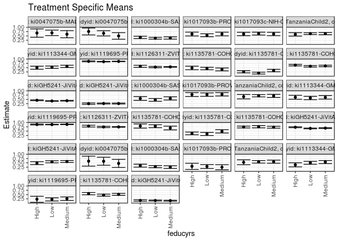

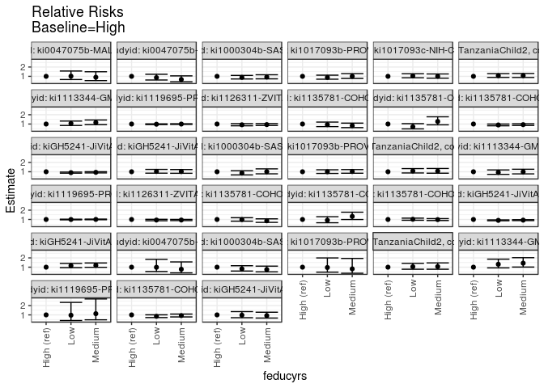

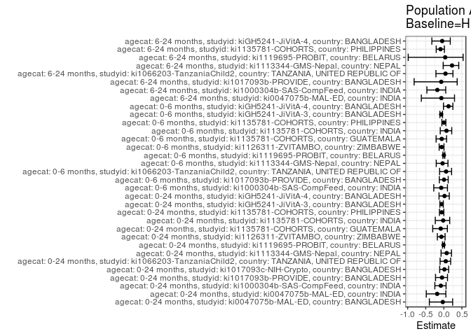

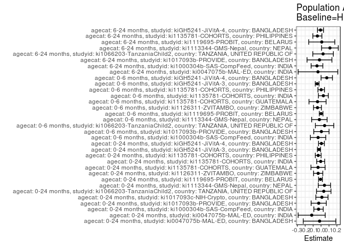

## Results Table

### Parameter: TSM

| agecat | studyid | country | intervention_level | baseline_level | estimate | ci_lower | ci_upper |
| --- | --- | --- | --- | --- | --- | --- | --- |
| 0-24 months | ki0047075b-MAL-ED | BANGLADESH | High | NA | 0.6666667 | 0.4235357 | 0.9097976 |
| 0-24 months | ki0047075b-MAL-ED | BANGLADESH | Low | NA | 0.6785714 | 0.5198822 | 0.8372607 |
| 0-24 months | ki0047075b-MAL-ED | BANGLADESH | Medium | NA | 0.6000000 | 0.3909534 | 0.8090466 |
| 0-24 months | ki0047075b-MAL-ED | INDIA | High | NA | 0.7586207 | 0.5584813 | 0.9587601 |
| 0-24 months | ki0047075b-MAL-ED | INDIA | Low | NA | 0.6521739 | 0.5001446 | 0.8042032 |
| 0-24 months | ki0047075b-MAL-ED | INDIA | Medium | NA | 0.5000000 | 0.3092033 | 0.6907967 |
| 0-24 months | ki1000304b-SAS-CompFeed | INDIA | High | NA | 0.4136245 | 0.3455805 | 0.4816685 |
| 0-24 months | ki1000304b-SAS-CompFeed | INDIA | Low | NA | 0.3664898 | 0.3147710 | 0.4182085 |
| 0-24 months | ki1000304b-SAS-CompFeed | INDIA | Medium | NA | 0.3817296 | 0.3170685 | 0.4463907 |
| 0-24 months | ki1017093b-PROVIDE | BANGLADESH | High | NA | 0.6106248 | 0.4990122 | 0.7222374 |
| 0-24 months | ki1017093b-PROVIDE | BANGLADESH | Low | NA | 0.5390076 | 0.4542008 | 0.6238143 |
| 0-24 months | ki1017093b-PROVIDE | BANGLADESH | Medium | NA | 0.6111074 | 0.5037344 | 0.7184803 |
| 0-24 months | ki1017093c-NIH-Crypto | BANGLADESH | High | NA | 0.6117629 | 0.5124141 | 0.7111118 |
| 0-24 months | ki1017093c-NIH-Crypto | BANGLADESH | Low | NA | 0.6358179 | 0.5527774 | 0.7188584 |
| 0-24 months | ki1017093c-NIH-Crypto | BANGLADESH | Medium | NA | 0.6128957 | 0.5159606 | 0.7098308 |
| 0-24 months | ki1066203-TanzaniaChild2 | TANZANIA, UNITED REPUBLIC OF | High | NA | 0.5930273 | 0.4928354 | 0.6932192 |
| 0-24 months | ki1066203-TanzaniaChild2 | TANZANIA, UNITED REPUBLIC OF | Low | NA | 0.6335073 | 0.5815720 | 0.6854425 |
| 0-24 months | ki1066203-TanzaniaChild2 | TANZANIA, UNITED REPUBLIC OF | Medium | NA | 0.6345866 | 0.5690000 | 0.7001731 |
| 0-24 months | ki1113344-GMS-Nepal | NEPAL | High | NA | 0.4970812 | 0.4076034 | 0.5865590 |
| 0-24 months | ki1113344-GMS-Nepal | NEPAL | Low | NA | 0.5258449 | 0.4573571 | 0.5943327 |
| 0-24 months | ki1113344-GMS-Nepal | NEPAL | Medium | NA | 0.5758206 | 0.5085345 | 0.6431068 |
| 0-24 months | ki1119695-PROBIT | BELARUS | High | NA | 0.8667953 | 0.8406649 | 0.8929257 |
| 0-24 months | ki1119695-PROBIT | BELARUS | Low | NA | 0.8494073 | 0.8325904 | 0.8662241 |
| 0-24 months | ki1119695-PROBIT | BELARUS | Medium | NA | 0.8643012 | 0.8490644 | 0.8795381 |
| 0-24 months | ki1126311-ZVITAMBO | ZIMBABWE | High | NA | 0.5786981 | 0.5182330 | 0.6391632 |
| 0-24 months | ki1126311-ZVITAMBO | ZIMBABWE | Low | NA | 0.5327090 | 0.4963870 | 0.5690309 |
| 0-24 months | ki1126311-ZVITAMBO | ZIMBABWE | Medium | NA | 0.5443649 | 0.5256764 | 0.5630534 |
| 0-24 months | ki1135781-COHORTS | GUATEMALA | High | NA | 0.4821400 | 0.3782106 | 0.5860695 |
| 0-24 months | ki1135781-COHORTS | GUATEMALA | Low | NA | 0.4508890 | 0.3772245 | 0.5245534 |
| 0-24 months | ki1135781-COHORTS | GUATEMALA | Medium | NA | 0.3971244 | 0.3129126 | 0.4813361 |

[output cut: 69 more lines]

### Parameter: E(Y)

| agecat | studyid | country | intervention_level | baseline_level | estimate | ci_lower | ci_upper |
| --- | --- | --- | --- | --- | --- | --- | --- |
| 0-24 months | ki0047075b-MAL-ED | BANGLADESH | NA | NA | 0.6478873 | 0.5336007 | 0.7621739 |
| 0-24 months | ki0047075b-MAL-ED | INDIA | NA | NA | 0.6407767 | 0.5352377 | 0.7463157 |
| 0-24 months | ki1000304b-SAS-CompFeed | INDIA | NA | NA | 0.3822441 | 0.3470990 | 0.4173892 |
| 0-24 months | ki1017093b-PROVIDE | BANGLADESH | NA | NA | 0.5811688 | 0.5245443 | 0.6377934 |
| 0-24 months | ki1017093c-NIH-Crypto | BANGLADESH | NA | NA | 0.6225806 | 0.5684562 | 0.6767051 |
| 0-24 months | ki1066203-TanzaniaChild2 | TANZANIA, UNITED REPUBLIC OF | NA | NA | 0.6272855 | 0.5895954 | 0.6649756 |
| 0-24 months | ki1113344-GMS-Nepal | NEPAL | NA | NA | 0.5397816 | 0.4973714 | 0.5821918 |
| 0-24 months | ki1119695-PROBIT | BELARUS | NA | NA | 0.8600563 | 0.8497279 | 0.8703846 |
| 0-24 months | ki1126311-ZVITAMBO | ZIMBABWE | NA | NA | 0.5425532 | 0.5258421 | 0.5592643 |
| 0-24 months | ki1135781-COHORTS | GUATEMALA | NA | NA | 0.4441341 | 0.3908676 | 0.4974005 |
| 0-24 months | ki1135781-COHORTS | INDIA | NA | NA | 0.2560297 | 0.2186976 | 0.2933617 |
| 0-24 months | ki1135781-COHORTS | PHILIPPINES | NA | NA | 0.6092757 | 0.5839352 | 0.6346162 |
| 0-24 months | kiGH5241-JiVitA-3 | BANGLADESH | NA | NA | 0.4230769 | 0.4117323 | 0.4344216 |
| 0-24 months | kiGH5241-JiVitA-4 | BANGLADESH | NA | NA | 0.2581128 | 0.2384369 | 0.2777888 |
| 0-6 months | ki1000304b-SAS-CompFeed | INDIA | NA | NA | 0.5147059 | 0.4610948 | 0.5683169 |
| 0-6 months | ki1017093b-PROVIDE | BANGLADESH | NA | NA | 0.7837838 | 0.7252863 | 0.8422812 |
| 0-6 months | ki1066203-TanzaniaChild2 | TANZANIA, UNITED REPUBLIC OF | NA | NA | 0.7029412 | 0.6536517 | 0.7522307 |
| 0-6 months | ki1113344-GMS-Nepal | NEPAL | NA | NA | 0.6045627 | 0.5449300 | 0.6641955 |
| 0-6 months | ki1119695-PROBIT | BELARUS | NA | NA | 0.8851500 | 0.8753163 | 0.8949836 |
| 0-6 months | ki1126311-ZVITAMBO | ZIMBABWE | NA | NA | 0.7459860 | 0.7286870 | 0.7632850 |
| 0-6 months | ki1135781-COHORTS | GUATEMALA | NA | NA | 0.7512438 | 0.6914852 | 0.8110023 |
| 0-6 months | ki1135781-COHORTS | INDIA | NA | NA | 0.3954155 | 0.3440450 | 0.4467860 |
| 0-6 months | ki1135781-COHORTS | PHILIPPINES | NA | NA | 0.7402032 | 0.7074271 | 0.7729793 |
| 0-6 months | kiGH5241-JiVitA-3 | BANGLADESH | NA | NA | 0.6767743 | 0.6631857 | 0.6903630 |
| 0-6 months | kiGH5241-JiVitA-4 | BANGLADESH | NA | NA | 0.5561798 | 0.5140008 | 0.5983587 |
| 6-24 months | ki0047075b-MAL-ED | INDIA | NA | NA | 0.5614035 | 0.4130317 | 0.7097753 |
| 6-24 months | ki1000304b-SAS-CompFeed | INDIA | NA | NA | 0.2866242 | 0.2446853 | 0.3285631 |
| 6-24 months | ki1017093b-PROVIDE | BANGLADESH | NA | NA | 0.2764228 | 0.1950773 | 0.3577682 |
| 6-24 months | ki1066203-TanzaniaChild2 | TANZANIA, UNITED REPUBLIC OF | NA | NA | 0.5579515 | 0.5056058 | 0.6102972 |
| 6-24 months | ki1113344-GMS-Nepal | NEPAL | NA | NA | 0.4947090 | 0.4399319 | 0.5494861 |
| 6-24 months | ki1119695-PROBIT | BELARUS | NA | NA | 0.2363636 | 0.1715730 | 0.3011543 |
| 6-24 months | ki1135781-COHORTS | PHILIPPINES | NA | NA | 0.5073446 | 0.4725123 | 0.5421770 |
| 6-24 months | kiGH5241-JiVitA-4 | BANGLADESH | NA | NA | 0.1497617 | 0.1318544 | 0.1676691 |

### Parameter: RR

| agecat | studyid | country | intervention_level | baseline_level | estimate | ci_lower | ci_upper |
| --- | --- | --- | --- | --- | --- | --- | --- |
| 0-24 months | ki0047075b-MAL-ED | BANGLADESH | High | High | 1.0000000 | 1.0000000 | 1.0000000 |
| 0-24 months | ki0047075b-MAL-ED | BANGLADESH | Low | High | 1.0178571 | 0.6597795 | 1.5702719 |
| 0-24 months | ki0047075b-MAL-ED | BANGLADESH | Medium | High | 0.9000000 | 0.5432668 | 1.4909800 |
| 0-24 months | ki0047075b-MAL-ED | INDIA | High | High | 1.0000000 | 1.0000000 | 1.0000000 |
| 0-24 months | ki0047075b-MAL-ED | INDIA | Low | High | 0.8596838 | 0.6045511 | 1.2224875 |
| 0-24 months | ki0047075b-MAL-ED | INDIA | Medium | High | 0.6590909 | 0.4141553 | 1.0488839 |
| 0-24 months | ki1000304b-SAS-CompFeed | INDIA | High | High | 1.0000000 | 1.0000000 | 1.0000000 |
| 0-24 months | ki1000304b-SAS-CompFeed | INDIA | Low | High | 0.8860446 | 0.7146270 | 1.0985801 |
| 0-24 months | ki1000304b-SAS-CompFeed | INDIA | Medium | High | 0.9228892 | 0.7307507 | 1.1655472 |
| 0-24 months | ki1017093b-PROVIDE | BANGLADESH | High | High | 1.0000000 | 1.0000000 | 1.0000000 |
| 0-24 months | ki1017093b-PROVIDE | BANGLADESH | Low | High | 0.8827149 | 0.6935391 | 1.1234920 |
| 0-24 months | ki1017093b-PROVIDE | BANGLADESH | Medium | High | 1.0007903 | 0.7768732 | 1.2892468 |
| 0-24 months | ki1017093c-NIH-Crypto | BANGLADESH | High | High | 1.0000000 | 1.0000000 | 1.0000000 |
| 0-24 months | ki1017093c-NIH-Crypto | BANGLADESH | Low | High | 1.0393208 | 0.8449363 | 1.2784251 |
| 0-24 months | ki1017093c-NIH-Crypto | BANGLADESH | Medium | High | 1.0018516 | 0.8014582 | 1.2523505 |
| 0-24 months | ki1066203-TanzaniaChild2 | TANZANIA, UNITED REPUBLIC OF | High | High | 1.0000000 | 1.0000000 | 1.0000000 |
| 0-24 months | ki1066203-TanzaniaChild2 | TANZANIA, UNITED REPUBLIC OF | Low | High | 1.0682599 | 0.8853468 | 1.2889630 |
| 0-24 months | ki1066203-TanzaniaChild2 | TANZANIA, UNITED REPUBLIC OF | Medium | High | 1.0700799 | 0.8778427 | 1.3044148 |
| 0-24 months | ki1113344-GMS-Nepal | NEPAL | High | High | 1.0000000 | 1.0000000 | 1.0000000 |
| 0-24 months | ki1113344-GMS-Nepal | NEPAL | Low | High | 1.0578653 | 0.8472006 | 1.3209138 |
| 0-24 months | ki1113344-GMS-Nepal | NEPAL | Medium | High | 1.1584036 | 0.9344935 | 1.4359639 |
| 0-24 months | ki1119695-PROBIT | BELARUS | High | High | 1.0000000 | 1.0000000 | 1.0000000 |
| 0-24 months | ki1119695-PROBIT | BELARUS | Low | High | 0.9799399 | 0.9453518 | 1.0157934 |
| 0-24 months | ki1119695-PROBIT | BELARUS | Medium | High | 0.9971227 | 0.9630860 | 1.0323623 |
| 0-24 months | ki1126311-ZVITAMBO | ZIMBABWE | High | High | 1.0000000 | 1.0000000 | 1.0000000 |
| 0-24 months | ki1126311-ZVITAMBO | ZIMBABWE | Low | High | 0.9205300 | 0.8143593 | 1.0405425 |
| 0-24 months | ki1126311-ZVITAMBO | ZIMBABWE | Medium | High | 0.9406716 | 0.8447202 | 1.0475222 |
| 0-24 months | ki1135781-COHORTS | GUATEMALA | High | High | 1.0000000 | 1.0000000 | 1.0000000 |
| 0-24 months | ki1135781-COHORTS | GUATEMALA | Low | High | 0.9351826 | 0.7228502 | 1.2098864 |
| 0-24 months | ki1135781-COHORTS | GUATEMALA | Medium | High | 0.8236702 | 0.6167209 | 1.1000642 |

[output cut: 69 more lines]

### Parameter: PAR

| agecat | studyid | country | intervention_level | baseline_level | estimate | ci_lower | ci_upper |
| --- | --- | --- | --- | --- | --- | --- | --- |
| 0-24 months | ki0047075b-MAL-ED | BANGLADESH | High | NA | -0.0187793 | -0.2243504 | 0.1867917 |
| 0-24 months | ki0047075b-MAL-ED | INDIA | High | NA | -0.1178440 | -0.2885817 | 0.0528938 |
| 0-24 months | ki1000304b-SAS-CompFeed | INDIA | High | NA | -0.0313804 | -0.0903157 | 0.0275550 |
| 0-24 months | ki1017093b-PROVIDE | BANGLADESH | High | NA | -0.0294559 | -0.1251925 | 0.0662806 |
| 0-24 months | ki1017093c-NIH-Crypto | BANGLADESH | High | NA | 0.0108177 | -0.0657108 | 0.0873462 |
| 0-24 months | ki1066203-TanzaniaChild2 | TANZANIA, UNITED REPUBLIC OF | High | NA | 0.0342582 | -0.0568505 | 0.1253670 |
| 0-24 months | ki1113344-GMS-Nepal | NEPAL | High | NA | 0.0427004 | -0.0345053 | 0.1199061 |
| 0-24 months | ki1119695-PROBIT | BELARUS | High | NA | -0.0067390 | -0.0307766 | 0.0172986 |
| 0-24 months | ki1126311-ZVITAMBO | ZIMBABWE | High | NA | -0.0361449 | -0.0943101 | 0.0220202 |
| 0-24 months | ki1135781-COHORTS | GUATEMALA | High | NA | -0.0380059 | -0.1273304 | 0.0513185 |
| 0-24 months | ki1135781-COHORTS | INDIA | High | NA | -0.0043661 | -0.0551021 | 0.0463699 |
| 0-24 months | ki1135781-COHORTS | PHILIPPINES | High | NA | -0.0357142 | -0.0725204 | 0.0010919 |
| 0-24 months | kiGH5241-JiVitA-3 | BANGLADESH | High | NA | -0.0260578 | -0.0460119 | -0.0061038 |
| 0-24 months | kiGH5241-JiVitA-4 | BANGLADESH | High | NA | 0.0049728 | -0.0314357 | 0.0413813 |
| 0-6 months | ki1000304b-SAS-CompFeed | INDIA | High | NA | -0.0372268 | -0.1342113 | 0.0597578 |
| 0-6 months | ki1017093b-PROVIDE | BANGLADESH | High | NA | 0.0045548 | -0.0915059 | 0.1006156 |
| 0-6 months | ki1066203-TanzaniaChild2 | TANZANIA, UNITED REPUBLIC OF | High | NA | 0.0446992 | -0.0711570 | 0.1605554 |
| 0-6 months | ki1113344-GMS-Nepal | NEPAL | High | NA | -0.0211312 | -0.1188180 | 0.0765555 |
| 0-6 months | ki1119695-PROBIT | BELARUS | High | NA | 0.0009018 | -0.0224614 | 0.0242650 |
| 0-6 months | ki1126311-ZVITAMBO | ZIMBABWE | High | NA | -0.0449000 | -0.0946752 | 0.0048751 |
| 0-6 months | ki1135781-COHORTS | GUATEMALA | High | NA | -0.0442108 | -0.1522742 | 0.0638527 |
| 0-6 months | ki1135781-COHORTS | INDIA | High | NA | 0.0291027 | -0.0333418 | 0.0915473 |
| 0-6 months | ki1135781-COHORTS | PHILIPPINES | High | NA | 0.0019008 | -0.0389123 | 0.0427139 |
| 0-6 months | kiGH5241-JiVitA-3 | BANGLADESH | High | NA | -0.0490281 | -0.0732179 | -0.0248383 |
| 0-6 months | kiGH5241-JiVitA-4 | BANGLADESH | High | NA | 0.0722632 | 0.0004923 | 0.1440342 |
| 6-24 months | ki0047075b-MAL-ED | INDIA | High | NA | -0.0385965 | -0.2887294 | 0.2115364 |
| 6-24 months | ki1000304b-SAS-CompFeed | INDIA | High | NA | -0.0514450 | -0.1253629 | 0.0224729 |
| 6-24 months | ki1017093b-PROVIDE | BANGLADESH | High | NA | -0.0198735 | -0.1770318 | 0.1372847 |
| 6-24 months | ki1066203-TanzaniaChild2 | TANZANIA, UNITED REPUBLIC OF | High | NA | 0.0257397 | -0.1040242 | 0.1555036 |
| 6-24 months | ki1113344-GMS-Nepal | NEPAL | High | NA | 0.1123070 | 0.0074688 | 0.2171452 |
| 6-24 months | ki1119695-PROBIT | BELARUS | High | NA | 0.0090909 | -0.1555312 | 0.1737130 |
| 6-24 months | ki1135781-COHORTS | PHILIPPINES | High | NA | -0.0463006 | -0.1034342 | 0.0108331 |
| 6-24 months | kiGH5241-JiVitA-4 | BANGLADESH | High | NA | -0.0068409 | -0.0446954 | 0.0310136 |

### Parameter: PAF

| agecat | studyid | country | intervention_level | baseline_level | estimate | ci_lower | ci_upper |
| --- | --- | --- | --- | --- | --- | --- | --- |
| 0-24 months | ki0047075b-MAL-ED | BANGLADESH | High | NA | -0.0289855 | -0.4001352 | 0.2437793 |
| 0-24 months | ki0047075b-MAL-ED | INDIA | High | NA | -0.1839080 | -0.4851250 | 0.0562153 |
| 0-24 months | ki1000304b-SAS-CompFeed | INDIA | High | NA | -0.0820951 | -0.2481805 | 0.0618907 |
| 0-24 months | ki1017093b-PROVIDE | BANGLADESH | High | NA | -0.0506840 | -0.2290719 | 0.1018127 |
| 0-24 months | ki1017093c-NIH-Crypto | BANGLADESH | High | NA | 0.0173756 | -0.1137995 | 0.1331019 |
| 0-24 months | ki1066203-TanzaniaChild2 | TANZANIA, UNITED REPUBLIC OF | High | NA | 0.0546135 | -0.1026002 | 0.1894109 |
| 0-24 months | ki1113344-GMS-Nepal | NEPAL | High | NA | 0.0791069 | -0.0760613 | 0.2118998 |
| 0-24 months | ki1119695-PROBIT | BELARUS | High | NA | -0.0078356 | -0.0361761 | 0.0197298 |
| 0-24 months | ki1126311-ZVITAMBO | ZIMBABWE | High | NA | -0.0666201 | -0.1794284 | 0.0353985 |
| 0-24 months | ki1135781-COHORTS | GUATEMALA | High | NA | -0.0855731 | -0.3068643 | 0.0982468 |
| 0-24 months | ki1135781-COHORTS | INDIA | High | NA | -0.0170530 | -0.2356513 | 0.1628732 |
| 0-24 months | ki1135781-COHORTS | PHILIPPINES | High | NA | -0.0586175 | -0.1208254 | 0.0001377 |
| 0-24 months | kiGH5241-JiVitA-3 | BANGLADESH | High | NA | -0.0615913 | -0.1098294 | -0.0154498 |
| 0-24 months | kiGH5241-JiVitA-4 | BANGLADESH | High | NA | 0.0192660 | -0.1325184 | 0.1507077 |
| 0-6 months | ki1000304b-SAS-CompFeed | INDIA | High | NA | -0.0723263 | -0.2786685 | 0.1007180 |
| 0-6 months | ki1017093b-PROVIDE | BANGLADESH | High | NA | 0.0058113 | -0.1246419 | 0.1211326 |
| 0-6 months | ki1066203-TanzaniaChild2 | TANZANIA, UNITED REPUBLIC OF | High | NA | 0.0635888 | -0.1168573 | 0.2148810 |
| 0-6 months | ki1113344-GMS-Nepal | NEPAL | High | NA | -0.0349529 | -0.2097925 | 0.1146188 |
| 0-6 months | ki1119695-PROBIT | BELARUS | High | NA | 0.0010188 | -0.0257278 | 0.0270679 |
| 0-6 months | ki1126311-ZVITAMBO | ZIMBABWE | High | NA | -0.0601888 | -0.1291705 | 0.0045787 |
| 0-6 months | ki1135781-COHORTS | GUATEMALA | High | NA | -0.0588501 | -0.2133559 | 0.0759813 |
| 0-6 months | ki1135781-COHORTS | INDIA | High | NA | 0.0736004 | -0.0986591 | 0.2188513 |
| 0-6 months | ki1135781-COHORTS | PHILIPPINES | High | NA | 0.0025679 | -0.0541227 | 0.0562097 |
| 0-6 months | kiGH5241-JiVitA-3 | BANGLADESH | High | NA | -0.0724438 | -0.1089061 | -0.0371805 |
| 0-6 months | kiGH5241-JiVitA-4 | BANGLADESH | High | NA | 0.1299278 | -0.0103745 | 0.2507476 |
| 6-24 months | ki0047075b-MAL-ED | INDIA | High | NA | -0.0687500 | -0.6222290 | 0.2958907 |
| 6-24 months | ki1000304b-SAS-CompFeed | INDIA | High | NA | -0.1794858 | -0.4685547 | 0.0526831 |
| 6-24 months | ki1017093b-PROVIDE | BANGLADESH | High | NA | -0.0718954 | -0.8212752 | 0.3691454 |
| 6-24 months | ki1066203-TanzaniaChild2 | TANZANIA, UNITED REPUBLIC OF | High | NA | 0.0461326 | -0.2176267 | 0.2527569 |
| 6-24 months | ki1113344-GMS-Nepal | NEPAL | High | NA | 0.2270163 | -0.0181063 | 0.4131224 |
| 6-24 months | ki1119695-PROBIT | BELARUS | High | NA | 0.0384615 | -0.9840988 | 0.5340171 |
| 6-24 months | ki1135781-COHORTS | PHILIPPINES | High | NA | -0.0912606 | -0.2102011 | 0.0159903 |
| 6-24 months | kiGH5241-JiVitA-4 | BANGLADESH | High | NA | -0.0456785 | -0.3312312 | 0.1786223 |